# Assignment 8: Visualization - Making a bar race

*How to do it?*:

- Open the Rmarkdown file of this assignment (link) in Rstudio.
- Right under each **question**, insert a code chunk (you can use the hotkey `Ctrl + Alt + I` to add a code chunk) and code the solution for the question.
- `Knit` the rmarkdown file (hotkey: `Ctrl + Alt + K`) to export an html.
- Publish the html file to your Githiub Page.

*Submission*: Submit the link on Github of the assignment to Canvas

1. Install two packages `gganimate` and `gifski` then restart Rstudio. Using the `Adult Census Income` data, make an animation using `geom_point` and `transition_states`.

```r
library(gganimate)
library(gifski)
library(gapminder)
library(ggplot2)
library(tidyverse)
library(lubridate)
library(knitr)

df <- read_csv("https://bryantstats.github.io/math421/data/adult_census.csv")
```

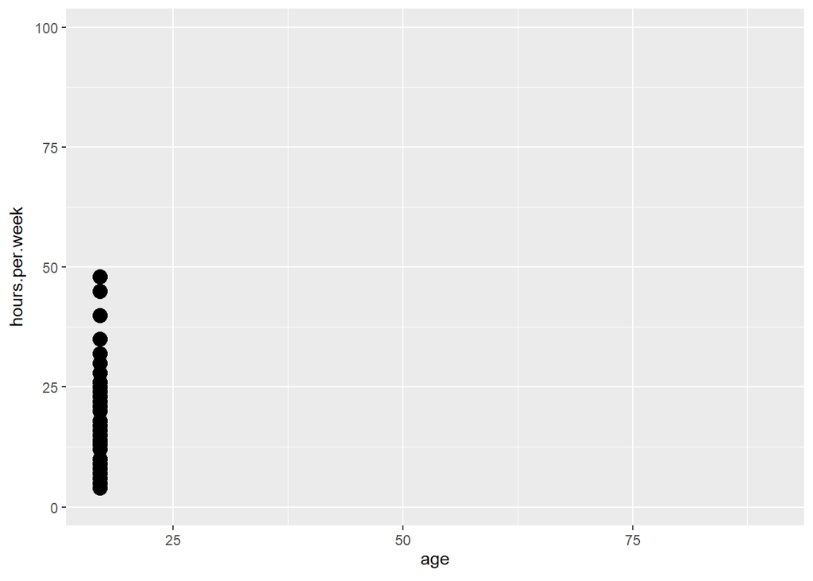

```r
g <- ggplot(df,
            aes(x = age,
                y = hours.per.week))+
  geom_point(size=4)+
  transition_states(age)
animate(g)
```

2. Using the `Adult Census Income` data, make an animation using `geom_bar` and `transition_states`.

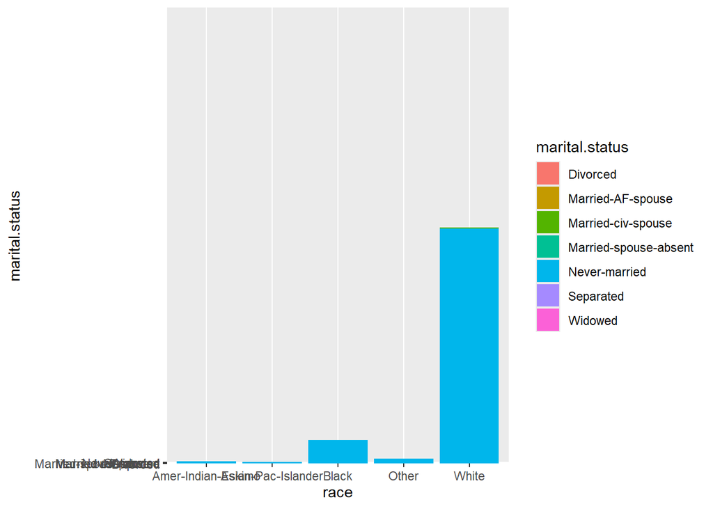

```r
g2 <- ggplot(df, aes(x=race,
                     y=marital.status,
                     fill=marital.status))+
  geom_col()+
  transition_states(age)
animate(g2)
```

3. Use the WHO’s dataset at [this link](https://covid19.who.int/WHO-COVID-19-global-data.csv). Make a top-10 bar race by months between countries on the number of deaths by Covid 19 in 2021.

```r
library(lubridate)
library(gganimate)
library(tidyverse)
library(dplyr)
library(ggplot2)
library(knitr)

df1 <- read_csv("https://covid19.who.int/WHO-COVID-19-global-data.csv")
df1 %>% filter(Date_reported>= "2021-01-01", Date_reported<="2021-12-31")
```

```
## # A tibble: 12,480 × 8
##    Date_reported Country_code Country     WHO_region New_cases Cumulative_cases
##    <date>        <chr>        <chr>       <chr>          <dbl>            <dbl>
##  1 2021-01-03    AF           Afghanistan EMRO             861            52709
##  2 2021-01-10    AF           Afghanistan EMRO             780            53489
##  3 2021-01-17    AF           Afghanistan EMRO             495            53984
##  4 2021-01-24    AF           Afghanistan EMRO             611            54595
##  5 2021-01-31    AF           Afghanistan EMRO             428            55023
##  6 2021-02-07    AF           Afghanistan EMRO             312            55335
##  7 2021-02-14    AF           Afghanistan EMRO             157            55492
##  8 2021-02-21    AF           Afghanistan EMRO             112            55604
##  9 2021-02-28    AF           Afghanistan EMRO             110            55714
## 10 2021-03-07    AF           Afghanistan EMRO             133            55847
## # ℹ 12,470 more rows
## # ℹ 2 more variables: New_deaths <dbl>, Cumulative_deaths <dbl>
```

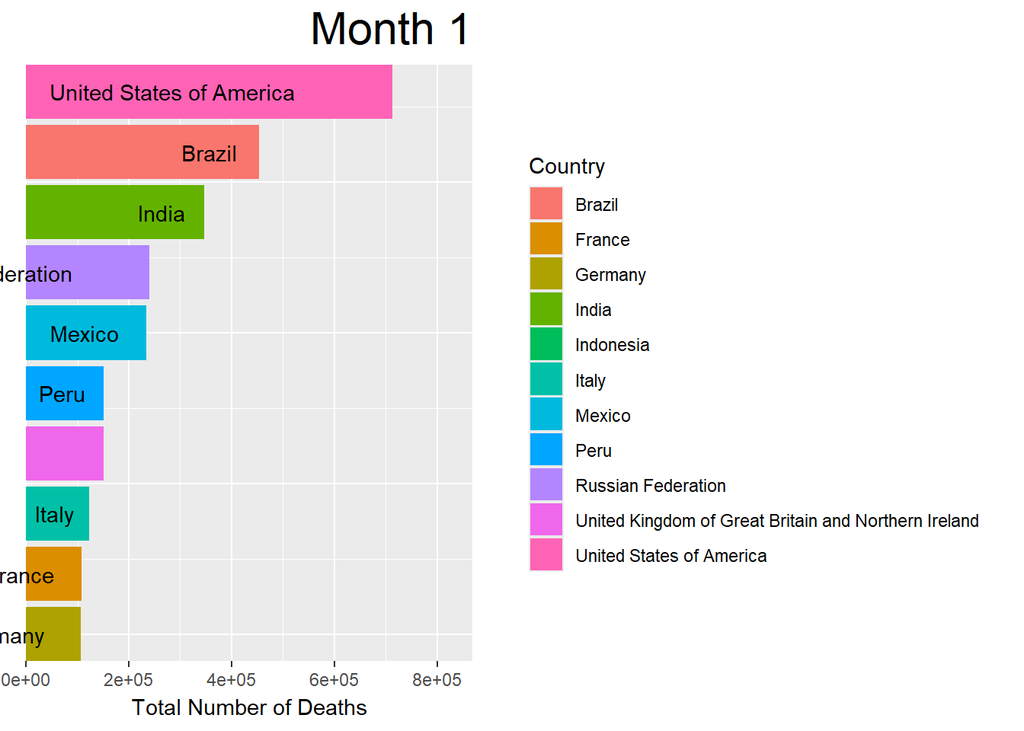

```r
df1$month <- month(df1$Date_reported)
d1 <- df1 %>% group_by(month,Country) %>% summarise(mean= mean(Cumulative_deaths))
d2 <- d1 %>% group_by(month) %>% mutate(rank= rank(-mean))
d3 <- d2 %>% filter(rank <= 10)

a1 <- d3 %>% ggplot(aes(x=rank, y=mean, group=Country, fill=Country, label=Country)) + geom_col()+
  geom_text(aes(y=mean, label=Country), hjust = 1.4)+
  coord_flip(clip = 'off', expand = FALSE)+scale_x_reverse()+
  labs(title = 'Month {closest_state}', x='', y='Total Number of Deaths', fill='Country')+
  theme(plot.title = element_text(hjust = 1, size = 22), axis.ticks.y = element_blank(),
        axis.text.y = element_blank())+
  transition_states(month)+
  ease_aes('cubic-in-out')

animate(a1, nframes=400)
```

4. Make a bar race using a dataset of your own interest. You may use the dataset that we use in class (https://covidtracking.com/data/download/all-states-history.csv) but you should make a different bar racev from ones in the slides.

```r
df1 <- read_csv("https://covid19.who.int/WHO-COVID-19-global-data.csv")

df1 %>% filter(Date_reported>= "2022-01-01", Date_reported<="2022-12-31")
```

```
## # A tibble: 12,480 × 8
##    Date_reported Country_code Country     WHO_region New_cases Cumulative_cases
##    <date>        <chr>        <chr>       <chr>          <dbl>            <dbl>
##  1 2022-01-02    AF           Afghanistan EMRO             210           158112
##  2 2022-01-09    AF           Afghanistan EMRO             233           158345
##  3 2022-01-16    AF           Afghanistan EMRO             333           158678
##  4 2022-01-23    AF           Afghanistan EMRO             870           159548
##  5 2022-01-30    AF           Afghanistan EMRO            2118           161666
##  6 2022-02-06    AF           Afghanistan EMRO            4046           165712
##  7 2022-02-13    AF           Afghanistan EMRO            4440           170152
##  8 2022-02-20    AF           Afghanistan EMRO            1778           171930
##  9 2022-02-27    AF           Afghanistan EMRO            1250           173180
## 10 2022-03-06    AF           Afghanistan EMRO            1167           174347
## # ℹ 12,470 more rows
## # ℹ 2 more variables: New_deaths <dbl>, Cumulative_deaths <dbl>
```

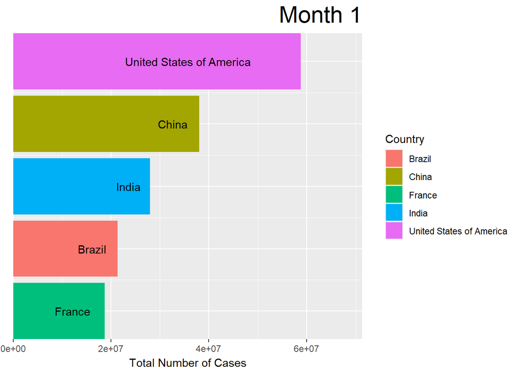

```r
df1$month <- month(df1$Date_reported)
d1 <- df1 %>% group_by(month,Country) %>% summarise(mean= mean(Cumulative_cases))

 d2 <- d1 %>% group_by(month) %>% mutate(rank= rank(-mean))
d3 <- d2 %>% filter(rank<=5)

 a1 <- d3 %>% ggplot(aes(x=rank, y=mean, group=Country, fill=Country, label=Country)) + geom_col()+
   geom_text(aes(y=mean, label=Country), hjust = 1.4)+
   coord_flip(clip = "off", expand = FALSE)+scale_x_reverse()+
   labs(title = "Month {closest_state}", x="", y="Total Number of Cases", fill="Country")+
  theme(plot.title = element_text(hjust = 1, size = 22), axis.ticks.y = element_blank(),
        axis.text.y = element_blank())+
  transition_states(month)+
  ease_aes("cubic-in-out")
 animate(a1, nframes=400)
```